# Importing Assets

All of Menpo's Input/Output functionality is stored in the `io` package. We frequently import this package as `mio`

```python
import menpo.io as mio
```

Menpo has a small cache of test assets shipped with it for example and testing purposes. You can get the filepath of this folder on your system easily

```python
data_dir = mio.data_dir_path()
print('Shipped data is at {}'.format(data_dir))
import os
os.listdir(data_dir)
```

```
Shipped data is at c:\users\james\documents\github\menpo\menpo\data
```

```
['breakingbad.jpg',
 'breakingbad.pts',
 'bunny.json',
 'bunny.obj',
 'bunny_no_nose.json',
 'einstein.jpg',
 'einstein.pts',
 'lenna.png',
 'takeo.ppm']
```

A convienience function is provided in the `io` package to make life easier

```python
builtin_assets = mio.ls_builtin_assets()
print(builtin_assets)
```

```
['breakingbad.jpg', 'breakingbad.pts', 'bunny.json', 'bunny.obj', 'bunny_no_nose.json', 'einstein.jpg', 'einstein.pts', 'lenna.png', 'takeo.ppm']
```

`data_path_to(filename)` can be used to get a path to examples from the folder. For instance, let's say you want to get a path to the `bunny.obj` file...

```python
bunny_path = mio.data_path_to('bunny.obj')
print('A bunny lives at {}'.format(bunny_path))
```

```
A bunny lives at c:\users\james\documents\github\menpo\menpo\data\bunny.obj
```

*Single asset importers*

- `import_image`
- `import_mesh`
- `import_landmarks`
- `import_builtin_asset`

*Multi asset importers*

- `import_images`
- `import_meshes`
- `import_auto`

**Single Asset Importers**

Let's start by seeing how the basic single importers work.

```python
bunny = mio.import_mesh(bunny_path)
print(bunny)
```

```
TriMesh: n_points: 2503, n_dims: 3, n_tris: 4968
```

```python
%matplotlib qt
bunny.view()
```

```
WARNING:traits.has_traits:DEPRECATED: traits.has_traits.wrapped_class, 'the 'implements' class advisor has been deprecated. Use the 'provides' class decorator.
```

```
<menpo.visualize.viewmayavi.MayaviTriMeshViewer3d at 0x14e4b860>
```

This still feels a little bit like too much hard work though. For built in files just use `import_builtin_asset(asset_name)`, no need to deal with the paths manually

```python
same_bunny_less_hassle = mio.import_builtin_asset('bunny.obj')
print(same_bunny_less_hassle)
```

```
TriMesh: n_points: 2503, n_dims: 3, n_tris: 4968
```

All imported objects get stamped with a set of userful information - this can be found at the `ioinfo` attribute

```python
print(bunny.ioinfo)
```

```
filename: bunny
extension: .obj
dir: c:\users\james\documents\github\menpo\menpo\data
filepath: c:\users\james\documents\github\menpo\menpo\data\bunny.obj
```

Let's try a few more examples. How about provided images?

```
<menpo.visualize.viewmatplotlib.MatplotlibImageViewer2d at 0x19c8a860>
```

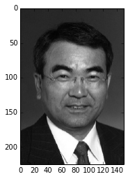

```python
%matplotlib inline
# builtin asset handles both images and meshes
takeo = mio.import_builtin_asset('takeo.ppm')
takeo.view()
```

```
<menpo.visualize.viewmatplotlib.MatplotlibImageViewer2d at 0x1e5b24a8>
```

[figure not shown]

```python
%matplotlib inline
bb = mio.import_builtin_asset('breakingbad.jpg')
bb.view()
```

Note that landmark files are automatically detected by the IO module and applied to assets. For instance, the *breakingbad.jpg* had alongside it a *breakingbad.pts* file...

```
breaking bad assets are: ['breakingbad.jpg', 'breakingbad.pts']
LandmarkManager: n_groups: 1
(PTS): LandmarkGroup: label: PTS, n_labels: 1, n_points: 68
```

[figure not shown]

```python
%matplotlib inline
print('breaking bad assets are: {}'.format(
[a for a in builtin_assets if a.startswith('breakingbad')]))
print(bb.landmarks)
bb.landmarks.view()
```

Of course, if we were feeling more verbose we could have used the `import_image(filepath)` function having found the breaking bad image for ourselves

```
Walter White lives at c:\users\james\documents\github\menpo\menpo\data\breakingbad.jpg
```

```
<menpo.visualize.viewmatplotlib.MatplotlibImageViewer2d at 0x1e700240>
```

[figure not shown]

```python
%matplotlib inline
new_mexico = mio.data_path_to('breakingbad.jpg')
print('Walter White lives at {}'.format(new_mexico))
walter_2 = mio.import_image(new_mexico)
walter_2.view()  # exactly the same!
```

The three importers we have looked at so far are for retrieving single items, and expect exact filepaths. If you provide an invalid path, or a path to something that can't be imported, you will get a `ValueError` explaining what went wrong

```python
try:
    mio.import_image('/I/bet/this/isnt/an/image/on/your/system.jpg')
except ValueError as e:
    print(e)
```

```
C:\I\bet\this\isnt\an\image\on\your\system.jpg is not a file
```

**Multi Asset importers**

The final three `import_*` functions are the bulk importers. All three are **generators**, which means they *yield* the files they find one at a time, and support `for` looping. All three also expect a glob pattern to match against.

```python
all_data_files = mio.data_dir_path() + '/*'
print('glob to find all inbuilt files: {}'.format(all_data_files))
for image in mio.import_images(all_data_files):
    print(image)
```

```
glob to find all inbuilt files: c:\users\james\documents\github\menpo\menpo\data/*
1920W x 1080H 2D MaskedImage with 3 channels. Attached mask 100.0% true
817W x 1024H 2D MaskedImage with 1 channels. Attached mask 100.0% true
512W x 512H 2D MaskedImage with 3 channels. Attached mask 100.0% true
150W x 225H 2D MaskedImage with 3 channels. Attached mask 100.0% true
```

Note that as we used `import_images()` all images in the data folder were returned to us one by one. If we want to get them all we can wrap the generator in a list constructor

```python
images = list(mio.import_images(all_data_files))
for image in images:
    print(image)
```

```
1920W x 1080H 2D MaskedImage with 3 channels. Attached mask 100.0% true
817W x 1024H 2D MaskedImage with 1 channels. Attached mask 100.0% true
512W x 512H 2D MaskedImage with 3 channels. Attached mask 100.0% true
150W x 225H 2D MaskedImage with 3 channels. Attached mask 100.0% true
```

Or we can use the generator to be selective on import. Often when importing large datasets of images we want to crop all the images in some way. It would be problematic to import all the images into memory at maximum size and then crop them en masse. With the generator we can crop as we go, and keep memory usage low

```python
cropped_images = []
for image in mio.import_images(all_data_files):
    image.crop((0, 0), (100, 100))
    cropped_images.append(image)
for image in cropped_images:
    print(image)
```

```
100W x 100H 2D MaskedImage with 3 channels. Attached mask 100.0% true
100W x 100H 2D MaskedImage with 1 channels. Attached mask 100.0% true
100W x 100H 2D MaskedImage with 3 channels. Attached mask 100.0% true
100W x 100H 2D MaskedImage with 3 channels. Attached mask 100.0% true
```

Of course, `import_meshes()` follows exactly the same rules

```python
for mesh in mio.import_meshes(all_data_files):
    print(mesh)
# note there is only one mesh in the data file at present!
```

```
TriMesh: n_points: 2503, n_dims: 3, n_tris: 4968
```

Sometimes, you may wish to import a mixed bag of data. This may include meshes, their textures, and other images. You want the meshes to have their textures attached, but you don't want the textures importing as seperate images in their own right. `import_auto()` sorts all this out for you

```python
for asset in mio.import_auto(all_data_files):
    print(asset)
```

```
TriMesh: n_points: 2503, n_dims: 3, n_tris: 4968
1920W x 1080H 2D MaskedImage with 3 channels. Attached mask 100.0% true
817W x 1024H 2D MaskedImage with 1 channels. Attached mask 100.0% true
512W x 512H 2D MaskedImage with 3 channels. Attached mask 100.0% true
150W x 225H 2D MaskedImage with 3 channels. Attached mask 100.0% true
```